# CellTag Processing and Clone Calling Pipeline

Siwanart Ma

2025-06-19

# CellTag Processing and Clone Calling Pipeline

This script processes CellTag matrices from multiple samples, which were the intermediate products of CellTag pipeline pulled from the HPC. It performs binarization and filtering, and identifies clones based on Jaccard similarity.

## Load libraries and source code of CellTag pipeline

```r
library(igraph)
library(proxy)
library(corrplot)
library(data.table)
library(CellTagR)
source("/Users/mayongzhi/Desktop/researchProject/integration/readmes/ScaleRNA_Rscript/CellTag source code/CellTagCloneCalling_Function.R")
```

## Data Aggregation from Multiple Directories

The result of CellTag pipeline from the last step was pulled from HPC. Loop through each directory and store them in a data list

```r
# Vector of directories
dirs <- list.dirs(path = "~/Desktop/researchProject/CellTag_practice/CellTag_all/results/",
                  recursive = FALSE)

# Initialize list to store data
data_list <- list()

# Loop through each directory
for (dir in dirs) {
  # Extract sample ID from the directory name
  sample_id <- basename(dir)

  # Find the .Rds file (assumes only one matching RDS per directory)
  rds_file <- list.files(path = dir, pattern = "\\.celltag\\.matrix\\.Rds$", full.names = TRUE)

  # Skip if no RDS found
  if (length(rds_file) == 0) {
    message("No RDS file found in: ", dir)
    next
  }
  # Read and tag the data
  mat <- as.data.frame(readRDS(rds_file[1]))
  mat$Sample <- sample_id

  # Append to list
  data_list[[sample_id]] <- mat
}
```

## Check the component of the data list

Show the sample IDs collected

```r
print(names(data_list))
```

```
##  [1] "CellTag-D10.ScaleRNA.33"          "CellTag-D10.ScaleRNA.34"
##  [3] "CellTag-D10.ScaleRNA.35"          "CellTag-D10.ScaleRNA.36"
##  [5] "CellTag-D10.ScaleRNA.37"          "CellTag-D10.ScaleRNA.38"
##  [7] "CellTag-D10.ScaleRNA.39"          "CellTag-D10.ScaleRNA.40"
##  [9] "CellTag-D2.ScaleRNA.41"           "CellTag-D2.ScaleRNA.42"
## [11] "CellTag-D2.ScaleRNA.43"           "CellTag-D2.ScaleRNA.44"
## [13] "CellTag-D2.ScaleRNA.45"           "CellTag-D2.ScaleRNA.46"
## [15] "CellTag-D2.ScaleRNA.47"           "CellTag-D2.ScaleRNA.48"
## [17] "CellTag-D6.ScaleRNA.49"           "CellTag-D6.ScaleRNA.50"
## [19] "CellTag-D6.ScaleRNA.51"           "CellTag-D6.ScaleRNA.52"
## [21] "CellTag-D6.ScaleRNA.53"           "CellTag-D6.ScaleRNA.54"
## [23] "CellTag-D6.ScaleRNA.55"           "CellTag-D6.ScaleRNA.56"
## [25] "CellTag-D8.ScaleRNA.57"           "CellTag-D8.ScaleRNA.58"
## [27] "CellTag-D8.ScaleRNA.59"           "CellTag-D8.ScaleRNA.60"
## [29] "CellTag-D8.ScaleRNA.61"           "CellTag-D8.ScaleRNA.62"
## [31] "CellTag-D8.ScaleRNA.63"           "CellTag-D8.ScaleRNA.64"
## [33] "CellTag-iPSCs-Frozen.ScaleRNA.65" "CellTag-iPSCs-Frozen.ScaleRNA.66"
## [35] "CellTag-iPSCs-Frozen.ScaleRNA.67" "CellTag-iPSCs-Frozen.ScaleRNA.68"
## [37] "CellTag-iPSCs-Frozen.ScaleRNA.69" "CellTag-iPSCs-Frozen.ScaleRNA.70"
## [39] "CellTag-iPSCs-Frozen.ScaleRNA.71" "CellTag-iPSCs-Frozen.ScaleRNA.72"
```

Show structure of the first sample

```r
str(data_list[[1]])
```

```
## 'data.frame':    8296 obs. of  4 variables:
##  $ Cell.BC : chr  "6C+5A+3D" "9G+5A+1B" "7M+5A+1A" "11K+5A+1A" ...
##  $ AATATCGG: num  1 0 0 0 0 0 0 0 0 0 ...
##  $ CCTTTCCC: num  0 1 0 0 0 0 0 0 0 0 ...
##  $ Sample  : chr  "CellTag-D10.ScaleRNA.33" "CellTag-D10.ScaleRNA.33" "CellTag-D10.ScaleRNA.33" "CellTag-D10.ScaleRNA.33" ...
```

## Preview the first sample in the data list

```r
# Show the first few rows of the first sample in the data list
print(head(data_list[[1]]))
```

```
##     Cell.BC AATATCGG CCTTTCCC                  Sample
## 1  6C+5A+3D        1        0 CellTag-D10.ScaleRNA.33
## 2  9G+5A+1B        0        1 CellTag-D10.ScaleRNA.33
## 3  7M+5A+1A        0        0 CellTag-D10.ScaleRNA.33
## 4 11K+5A+1A        0        0 CellTag-D10.ScaleRNA.33
## 5  5A+5A+1A        0        0 CellTag-D10.ScaleRNA.33
## 6 19F+5A+1A        0        0 CellTag-D10.ScaleRNA.33
```

## Combine Data into a Single Matrix

Make all data a united data frame First, collect all columns

```r
# Get the union of all column names across all data frames
all_cols <- unique(unlist(lapply(data_list, names)))
all_cols
```

```
##  [1] "Cell.BC"  "AATATCGG" "CCTTTCCC" "Sample"   "GAAGCTCT" "TGGGATCT"
##  [7] "ACCGGTTC" "GGCAAGTT" "CCAGCTCT" "AAAACTGG" "GTCGCTCT" "AGGGCTCT"
## [13] "TTCTATTG" "AGCCAAAG" "ACCGCTCT" "ACGGCTCT" "AGCGCTCT" "CACGCTCT"
## [19] "CATGCTCT" "CGCGCTCT" "GAATGCCA" "GCGGCTCT" "GGATGAGT" "TACGCTCT"
## [25] "TAGGCTCT" "TCCGCTCT" "TTAGCTCT" "AATTGTAT" "TCTTCTTC" "ATGGCCTT"
## [31] "TGACGGGA"
```

Let each data frame in the data list have all columns, and fill missing with 0. And then combine them.

```r
# Ensure every data frame has all columns (fill missing with 0)
data_list_filled <- lapply(data_list, function(df) {
  missing_cols <- setdiff(all_cols, names(df))
  for (col in missing_cols) {
    df[[col]] <- 0
  }

  # Reorder columns to match
  df <- df[, all_cols]
  return(df)
})

# Combine all data into one data frame
combined_data <- do.call(rbind, data_list_filled)
```

Look at the combined_data

```r
head(combined_data)
```

```
##                             Cell.BC AATATCGG CCTTTCCC                  Sample
## CellTag-D10.ScaleRNA.33.1  6C+5A+3D        1        0 CellTag-D10.ScaleRNA.33
## CellTag-D10.ScaleRNA.33.2  9G+5A+1B        0        1 CellTag-D10.ScaleRNA.33
## CellTag-D10.ScaleRNA.33.3  7M+5A+1A        0        0 CellTag-D10.ScaleRNA.33
## CellTag-D10.ScaleRNA.33.4 11K+5A+1A        0        0 CellTag-D10.ScaleRNA.33
## CellTag-D10.ScaleRNA.33.5  5A+5A+1A        0        0 CellTag-D10.ScaleRNA.33
## CellTag-D10.ScaleRNA.33.6 19F+5A+1A        0        0 CellTag-D10.ScaleRNA.33
##                           GAAGCTCT TGGGATCT ACCGGTTC GGCAAGTT CCAGCTCT AAAACTGG
## CellTag-D10.ScaleRNA.33.1        0        0        0        0        0        0
## CellTag-D10.ScaleRNA.33.2        0        0        0        0        0        0
## CellTag-D10.ScaleRNA.33.3        0        0        0        0        0        0
## CellTag-D10.ScaleRNA.33.4        0        0        0        0        0        0
## CellTag-D10.ScaleRNA.33.5        0        0        0        0        0        0
## CellTag-D10.ScaleRNA.33.6        0        0        0        0        0        0
##                           GTCGCTCT AGGGCTCT TTCTATTG AGCCAAAG ACCGCTCT ACGGCTCT
## CellTag-D10.ScaleRNA.33.1        0        0        0        0        0        0
## CellTag-D10.ScaleRNA.33.2        0        0        0        0        0        0
## CellTag-D10.ScaleRNA.33.3        0        0        0        0        0        0
## CellTag-D10.ScaleRNA.33.4        0        0        0        0        0        0
## CellTag-D10.ScaleRNA.33.5        0        0        0        0        0        0
## CellTag-D10.ScaleRNA.33.6        0        0        0        0        0        0
##                           AGCGCTCT CACGCTCT CATGCTCT CGCGCTCT GAATGCCA GCGGCTCT
## CellTag-D10.ScaleRNA.33.1        0        0        0        0        0        0
## CellTag-D10.ScaleRNA.33.2        0        0        0        0        0        0
## CellTag-D10.ScaleRNA.33.3        0        0        0        0        0        0
## CellTag-D10.ScaleRNA.33.4        0        0        0        0        0        0
## CellTag-D10.ScaleRNA.33.5        0        0        0        0        0        0
## CellTag-D10.ScaleRNA.33.6        0        0        0        0        0        0
##                           GGATGAGT TACGCTCT TAGGCTCT TCCGCTCT TTAGCTCT AATTGTAT
## CellTag-D10.ScaleRNA.33.1        0        0        0        0        0        0
## CellTag-D10.ScaleRNA.33.2        0        0        0        0        0        0
## CellTag-D10.ScaleRNA.33.3        0        0        0        0        0        0
## CellTag-D10.ScaleRNA.33.4        0        0        0        0        0        0
## CellTag-D10.ScaleRNA.33.5        0        0        0        0        0        0
## CellTag-D10.ScaleRNA.33.6        0        0        0        0        0        0
##                           TCTTCTTC ATGGCCTT TGACGGGA
## CellTag-D10.ScaleRNA.33.1        0        0        0
## CellTag-D10.ScaleRNA.33.2        0        0        0
## CellTag-D10.ScaleRNA.33.3        0        0        0
## CellTag-D10.ScaleRNA.33.4        0        0        0
## CellTag-D10.ScaleRNA.33.5        0        0        0
## CellTag-D10.ScaleRNA.33.6        0        0        0
```

## Preprocessing: Add Day Labels and Clean Columns

```r
# Set the barcodes as row names
mat <- combined_data
rownames(mat) <- mat$Cell.BC

# Extract differentiation day or iPSCs from the Sample column
mat$Day <- sub("CellTag-(D\\d+|iPSCs).*", "\\1", mat$Sample)
mat$Sample <- NULL

# View mat
head(mat)
```

```
##             Cell.BC AATATCGG CCTTTCCC GAAGCTCT TGGGATCT ACCGGTTC GGCAAGTT
## 6C+5A+3D   6C+5A+3D        1        0        0        0        0        0
## 9G+5A+1B   9G+5A+1B        0        1        0        0        0        0
## 7M+5A+1A   7M+5A+1A        0        0        0        0        0        0
## 11K+5A+1A 11K+5A+1A        0        0        0        0        0        0
## 5A+5A+1A   5A+5A+1A        0        0        0        0        0        0
## 19F+5A+1A 19F+5A+1A        0        0        0        0        0        0
##           CCAGCTCT AAAACTGG GTCGCTCT AGGGCTCT TTCTATTG AGCCAAAG ACCGCTCT
## 6C+5A+3D         0        0        0        0        0        0        0
## 9G+5A+1B         0        0        0        0        0        0        0
## 7M+5A+1A         0        0        0        0        0        0        0
## 11K+5A+1A        0        0        0        0        0        0        0
## 5A+5A+1A         0        0        0        0        0        0        0
## 19F+5A+1A        0        0        0        0        0        0        0
##           ACGGCTCT AGCGCTCT CACGCTCT CATGCTCT CGCGCTCT GAATGCCA GCGGCTCT
## 6C+5A+3D         0        0        0        0        0        0        0
## 9G+5A+1B         0        0        0        0        0        0        0
## 7M+5A+1A         0        0        0        0        0        0        0
## 11K+5A+1A        0        0        0        0        0        0        0
## 5A+5A+1A         0        0        0        0        0        0        0
## 19F+5A+1A        0        0        0        0        0        0        0
##           GGATGAGT TACGCTCT TAGGCTCT TCCGCTCT TTAGCTCT AATTGTAT TCTTCTTC
## 6C+5A+3D         0        0        0        0        0        0        0
## 9G+5A+1B         0        0        0        0        0        0        0
## 7M+5A+1A         0        0        0        0        0        0        0
## 11K+5A+1A        0        0        0        0        0        0        0
## 5A+5A+1A         0        0        0        0        0        0        0
## 19F+5A+1A        0        0        0        0        0        0        0
##           ATGGCCTT TGACGGGA Day
## 6C+5A+3D         0        0 D10
## 9G+5A+1B         0        0 D10
## 7M+5A+1A         0        0 D10
## 11K+5A+1A        0        0 D10
## 5A+5A+1A         0        0 D10
## 19F+5A+1A        0        0 D10
```

## Binary Conversion and Quality Metrics

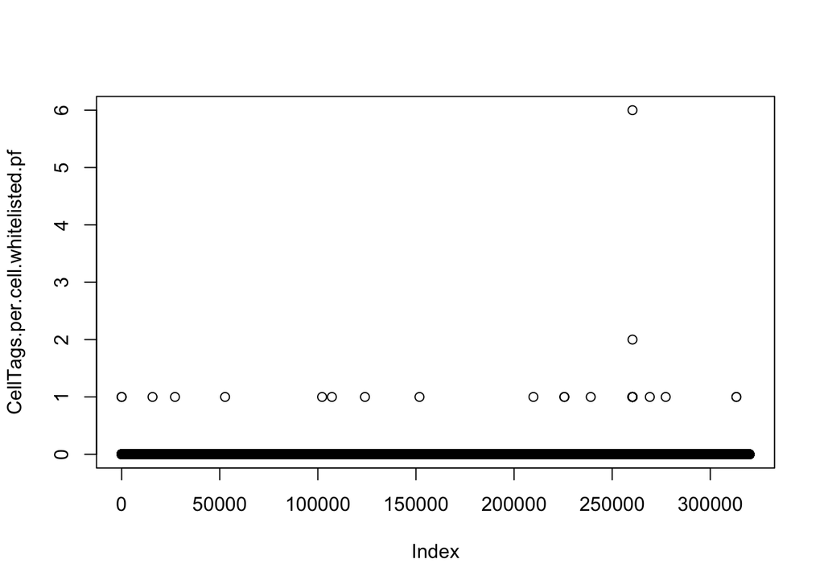

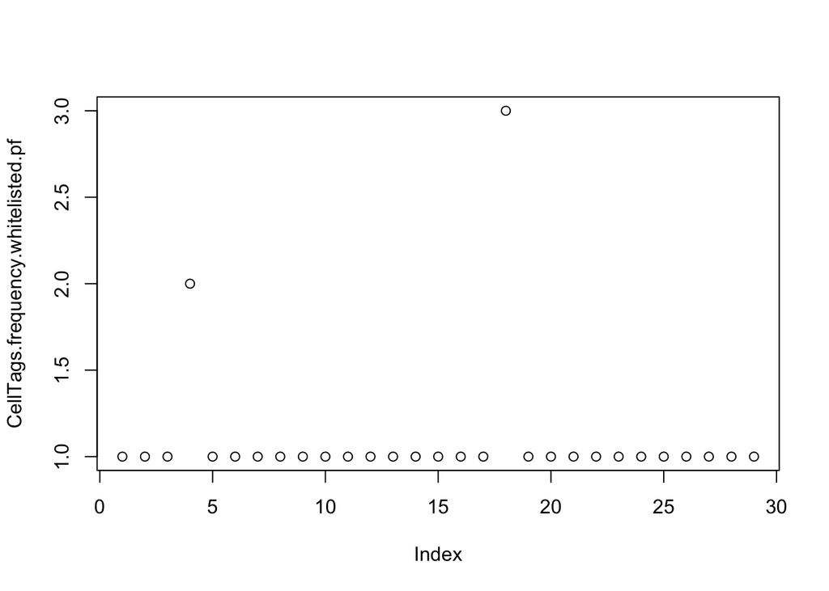

```
## [[1]]
## [1] 0.0001000131
##
## [[2]]
## [1] 1.103448
```

```r
# Copy mat and retain only CellTag columns
mat_tag <- mat
mat_tag$Day <- NULL
mat_tag$Cell.BC <- NULL

# Perform Single Cell Data Binarization
mat.bin <- SingleCellDataBinarization(mat_tag, 1)
MetricPlots(mat.bin)
```

## Whitelist Filtering

There might be some sequences match the format of CellTag motif, but don’t really contain the CellTag motif in the CellTag library. Filter them out with the whitelist.

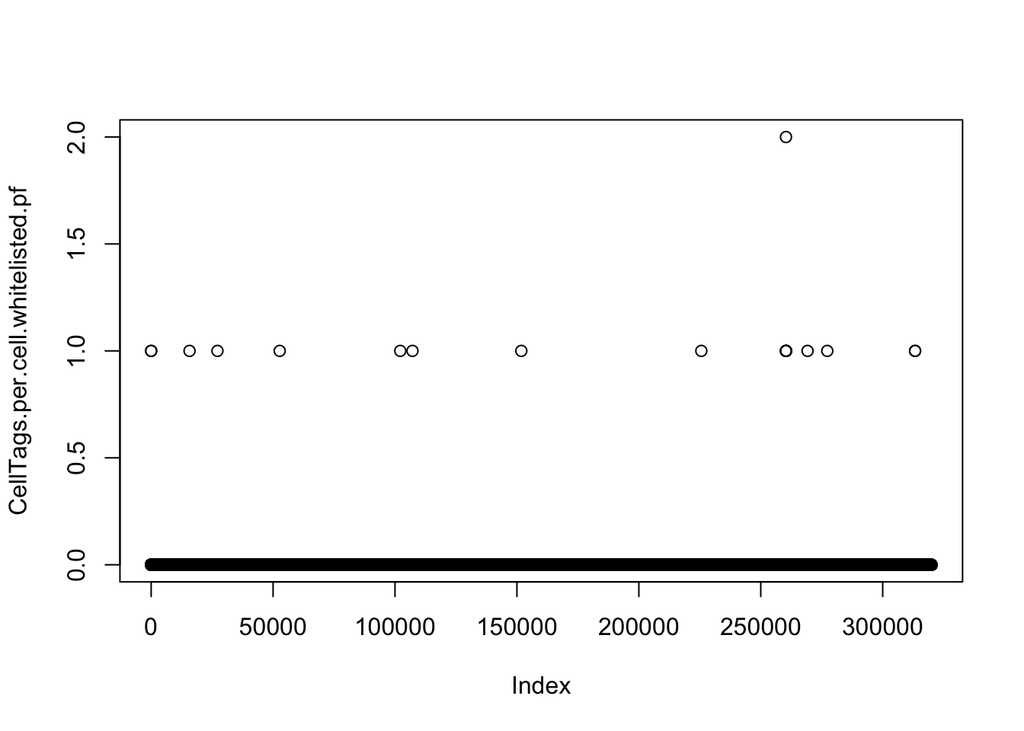

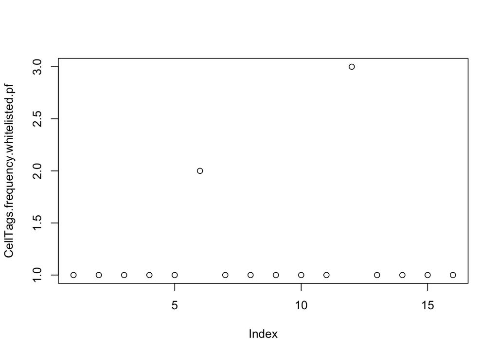

```
## [[1]]
## [1] 5.938279e-05
##
## [[2]]
## [1] 1.1875
```

```r
# Filter celltags by the whitelist
whitelist.path <- "/Users/mayongzhi/Desktop/researchProject/CellTag_practice/combined_celltags.csv"
mat.filt <- SingleCellDataWhitelist(celltag.dat = mat.bin,
                                    whitels.cell.tag.file = whitelist.path)
MetricPlots(mat.filt)
```

## CellTag Barcodes Remained After Filtering

```r
filtered_celltags <- colnames(mat.filt)
filtered_celltags
```

```
##  [1] "AAAACTGG" "ATGGCCTT" "AATTGTAT" "TCTTCTTC" "GGATGAGT" "TGGGATCT"
##  [7] "GAAGCTCT" "TGACGGGA" "GGCAAGTT" "AATATCGG" "ACCGCTCT" "CGCGCTCT"
## [13] "ACCGGTTC" "TTAGCTCT" "TTCTATTG" "CCTTTCCC"
```

## Final Filtering and Similarity Analysis

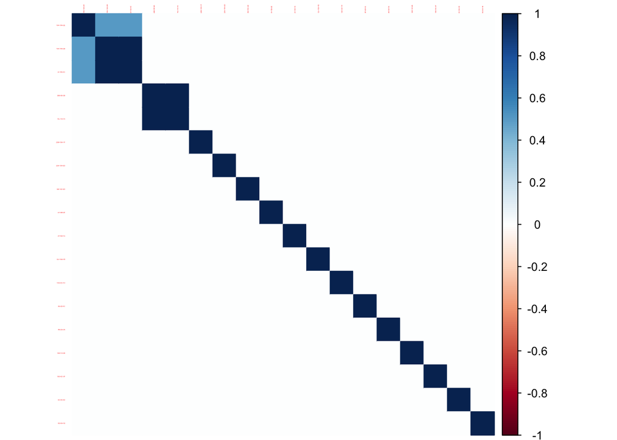

```
## $corr
##            19A+10A+2E 19A+10A+2B 2I+10A+3C 20B+5E+2B 16L+1A+1A 22M+10H+1F
## 19A+10A+2E        1.0        0.5       0.5         0         0          0
## 19A+10A+2B        0.5        1.0       1.0         0         0          0
## 2I+10A+3C         0.5        1.0       1.0         0         0          0
## 20B+5E+2B         0.0        0.0       0.0         1         1          0
## 16L+1A+1A         0.0        0.0       0.0         1         1          0
## 22M+10H+1F        0.0        0.0       0.0         0         0          1
## 22A+10H+2D        0.0        0.0       0.0         0         0          0
## 3M+10C+2D         0.0        0.0       0.0         0         0          0
## 4I+10B+2E         0.0        0.0       0.0         0         0          0
## 2I+10A+1A         0.0        0.0       0.0         0         0          0
## 12L+10A+1B        0.0        0.0       0.0         0         0          0
## 14O+4C+1H         0.0        0.0       0.0         0         0          0
## 3E+2D+3C          0.0        0.0       0.0         0         0          0
```

[output cut: 374 more lines]

```r
mat.filt <- MetricBasedFiltering(whitelisted.celltag.data = mat.filt, cutoff = 1, comparison = "greater")
mat.sim <- JaccardAnalysis(whitelisted.celltag.data = mat.filt, plot.corr = TRUE, id = "all")
```

## Clone Calling and Save Output

```r
output.path <- "~/Desktop/researchProject/integration/outputs/ScaleRNA/celltag/"
mat.clones <- CloneCalling(Jaccard.Matrix = mat.sim,
                           output.dir = output.path,
                           output.filename = "all.clones.csv",
                           correlation.cutoff = 0.1)

saveRDS(mat.sim, file.path(output.path, "mat_sim.rds"))
```

## Visualisation

### Count the Number of CellTags Expressed Per Cell

```r
# Convert mat to long format and retain Celltag expressed at least once
long_df <- mat %>%
  select(Day, all_of(filtered_celltags)) %>%
  pivot_longer(
    cols = -Day,
    names_to = "CellTag",
    values_to = "Count"
  ) %>%
  filter(Count >0)

head(long_df)
```

```
## # A tibble: 6 × 3
##   Day   CellTag  Count
##   <chr> <chr>    <dbl>
## 1 D10   AATATCGG     1
## 2 D10   CCTTTCCC     1
## 3 D10   GAAGCTCT     1
## 4 D10   TGGGATCT     1
## 5 D2    TGGGATCT     1
## 6 D2    ACCGGTTC     1
```

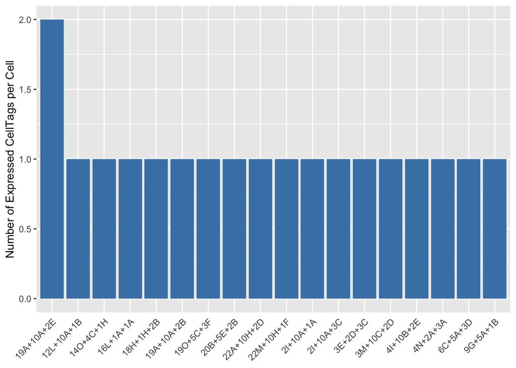

```r
celltag_counts <- mat.filt %>%
  mutate(Cell.BC = rownames(mat.filt),
         n_tags = rowSums(. > 0))

ggplot(celltag_counts, aes(x = reorder(Cell.BC, -n_tags), y = n_tags)) +
  geom_bar(stat = "identity") +
  geom_col(fill = "steelblue") +
  labs(x = NULL, y = "Number of Expressed CellTags per Cell") +
  theme(axis.text.x = element_text(angle = 45, hjust = 1),
        axis.ticks.x = element_blank())
```

### Count The Number of CellTags Expressed Per Sample

```r
# Create an empty vector to store results
tags_per_day <- setNames(numeric(0), character(0))

# Loop through each unique day
for (day in unique(mat$Day)) {

  # Subset cells for that day
  day_subset <- mat[mat$Day == day, filtered_celltags]

  # Count how many CellTags are expressed (non-zero in any cell)
  expressed_tags <- colSums(day_subset > 0) > 0
  tags_per_day[day] <- sum(expressed_tags)

}

# View results
print(tags_per_day)
```

```
##   D10    D2    D6    D8 iPSCs
##     4     2     2     1     8
```

Visualise it

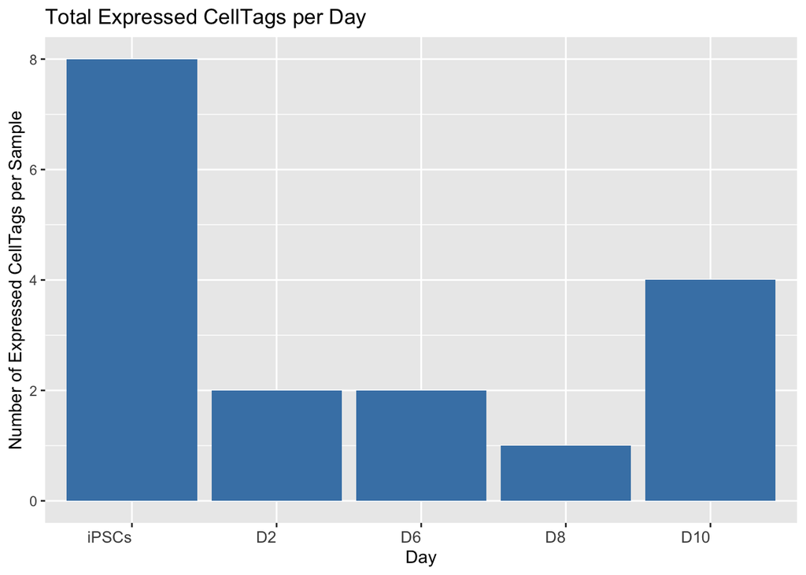

```r
tags_per_day <- as.data.frame(tags_per_day)
tags_per_day$Day <- factor(rownames(tags_per_day), levels = c("iPSCs", "D2", "D6", "D8", "D10"))

ggplot(tags_per_day, aes(x = Day, y = tags_per_day)) +
  geom_col(fill = "steelblue") +
  labs(title = "Total Expressed CellTags per Day",
       x = "Day", y = "Number of Expressed CellTags per Sample") +
  theme(axis.text.x = element_text(hjust = 1, size = 10))
```